# Getting started with population genetics using R

2020-09-17

## Contents

### 1. Why bother with R?

There are so many programs and software out there for analysing population genetic data and generating summary statistics. At first I was quite overwhelmed and unsure which path to take. Then I started learning and using R and I have not looked back since. Aside from the fact that R was the first programming language I learnt, there are several reasons why I like to use R for popgen analysis:

- A wealth of online help resources and tutorials
- Analyses easily replicated on new data sets
- Many options for creating publication quality figures and visualisations
- Code can be uploaded to online repositories for other people to reproduce your analysis
- Cross platform compatibility
- Free!

Nowadays, popgen R has dozens of packages that often allow you to do similar things but different packages can have their own formatting requirements and R objects. I recommend choosing one type of R object to conduct all your analyses with because converting between R objects can be difficult and frustrating (I work with `genind` objects from the adegenet package).

In this post, I cover some ‘bread-and-butter’ analyses for typical popgen data sets and highlight some of the R packages and functions I use to analyse such data using example data sets from published studies.

**Assumptions**  
This post assumes that you have installed R and RStudio and that you have some skills in R coding and functionality. To follow along, I recommend that you download the example data sets to a directory of your choice, create a new R script in the same directory and then set your working directory to the location of these files. To set your working directory in RStudio, for example, click Session > Set Working Directory > To Source File Location.

**Download example data sets**  
1. European lobster SNP genotypes in data.frame format  
2. Pink sea fan microsatellite genotypes in genepop format

**References**  
Jenkins TL, Ellis CD, Triantafyllidis A, Stevens JR (2019). [Single nucleotide polymorphisms reveal a genetic cline across the north‐east Atlantic and enable powerful population assignment in the European lobster](https://doi.org/https://doi.org/10.1111/eva.12849). *Evolutionary Applications* 12, 1881–1899.  
Holland LP, Jenkins TL, Stevens JR (2017). [Contrasting patterns of population structure and gene flow facilitate exploration of connectivity in two widely distributed temperate octocorals](https://doi.org/https://doi.org/10.1038/hdy.2017.14). *Heredity* 119, 35–48.

Back to Contents

### 2. Import genetic data

#### Install and load R packages

```r
library(adegenet)
library(poppr)
library(dplyr)
library(hierfstat)
library(reshape2)
library(ggplot2)
library(RColorBrewer)
library(scales)
```

#### Import lobster SNP genotypes

Import csv file containing SNP (single nucleotide polymorphism) genotypes.

```r
lobster = read.csv("Lobster_SNP_Genotypes.csv")
str(lobster)
```

```
## 'data.frame':    125280 obs. of  4 variables:
##  $ Site    : chr  "Ale" "Ale" "Ale" "Ale" ...
##  $ ID      : chr  "Ale04" "Ale04" "Ale04" "Ale04" ...
##  $ Locus   : int  3441 4173 6157 7502 7892 8953 9441 11071 11183 11291 ...
##  $ Genotype: chr  "GG" NA NA NA ...
```

Convert `data.frame` from long to wide format. The wide format contains one row for each individual and one column for each locus as well as a column for the ID and site labels.

```r
lobster_wide = reshape(lobster, idvar = c("ID","Site"), timevar = "Locus", direction = "wide", sep = "")
# Remove "Genotype" from column names
colnames(lobster_wide) = gsub("Genotype", "", colnames(lobster_wide))
```

Subset genotypes and only keep SNP loci used in Jenkins et al. 2019.

```r
# Subset genotypes
snpgeno = lobster_wide[ , 3:ncol(lobster_wide)]

# Keep only SNP loci used in Jenkins et al. 2019
snps_to_remove = c("25580","32362","41521","53889","65376","8953","21197","15531","22740","28357","33066","51507","53052","53263","21880","22323","22365")
snpgeno = snpgeno[ , !colnames(snpgeno) %in% snps_to_remove]
```

Create vectors of individual and site labels.

```r
ind = as.character(lobster_wide$ID) # individual ID
site = as.character(lobster_wide$Site) # site ID
```

Convert `data.frame` to `genind` object. Check that the genotypes for the first five individuals and loci are as expected.

```r
lobster_gen = df2genind(snpgeno, ploidy = 2, ind.names = ind, pop = site, sep = "")
lobster_gen$tab[1:5, 1:10]
```

```
##       3441.G 3441.A 4173.C 4173.T 6157.G 6157.C 7502.T 7502.C 7892.T 7892.A
## Ale04      2      0     NA     NA     NA     NA     NA     NA      2      0
## Ale05      1      1      2      0      1      1      2      0      1      1
## Ale06     NA     NA      2      0      2      0     NA     NA      2      0
## Ale08     NA     NA      0      2      2      0      2      0     NA     NA
## Ale13      2      0     NA     NA      2      0     NA     NA      2      0
```

Print basic info of the `genind` object.

```r
lobster_gen
## /// GENIND OBJECT /////////
##
##  // 1,305 individuals; 79 loci; 158 alleles; size: 945.1 Kb
##
##  // Basic content
##    @tab:  1305 x 158 matrix of allele counts
##    @loc.n.all: number of alleles per locus (range: 2-2)
##    @loc.fac: locus factor for the 158 columns of @tab
##    @all.names: list of allele names for each locus
##    @ploidy: ploidy of each individual  (range: 2-2)
##    @type:  codom
##    @call: df2genind(X = snpgeno, sep = "", ind.names = ind, pop = site,
##     ploidy = 2)
##
##  // Optional content
##    @pop: population of each individual (group size range: 7-41)

popNames(lobster_gen)
```

```
##  [1] "Ale"   "Ber"   "Brd"   "Cor"   "Cro"   "Eye"   "Flo"   "Gul"   "Heb"
## [10] "Hel"   "Hoo"   "Idr16" "Idr17" "Iom"   "Ios"   "Jer"   "Kav"   "Kil"
## [19] "Laz"   "Loo"   "Lyn"   "Lys"   "Mul"   "Oos"   "Ork"   "Pad"   "Pem"
## [28] "Sar13" "Sar17" "Sbs"   "She"   "Sin"   "Sky"   "Sul"   "Tar"   "The"
## [37] "Tor"   "Tro"   "Ven"   "Vig"
```

#### Import pink sea fan microsatellite genotypes

Import genepop file and convert to `genind` object. Check that the genotypes at locus Ever002 for three randomly selected individuals are as expected.

```r
seafan_gen = import2genind("Pinkseafan_13MicrosatLoci.gen", ncode = 3, quiet = TRUE)
set.seed(1)
tab(seafan_gen[loc = "Ever002"])[runif(3, 1, nInd(seafan_gen)), ]
```

```
##       Ever002.114 Ever002.117 Ever002.109 Ever002.105 Ever002.121
## Far10           2           0           0           0           0
## Han36           2           0           0           0           0
## Moh5            1           1           0           0           0
```

Print basic info of the `genind` object.

```r
seafan_gen
## /// GENIND OBJECT /////////
##
##  // 877 individuals; 13 loci; 114 alleles; size: 478.2 Kb
##
##  // Basic content
##    @tab:  877 x 114 matrix of allele counts
##    @loc.n.all: number of alleles per locus (range: 2-18)
##    @loc.fac: locus factor for the 114 columns of @tab
##    @all.names: list of allele names for each locus
##    @ploidy: ploidy of each individual  (range: 2-2)
##    @type:  codom
##    @call: read.genepop(file = file, ncode = 3, quiet = quiet)
##
##  // Optional content
##    @pop: population of each individual (group size range: 22-48)

popNames(seafan_gen)
```

```
##  [1] "ArmI_27"   "ArmII_43"  "ArmIII_41" "Bla29"     "Bov40"     "Bre43"
##  [7] "Far44"     "Fla23"     "Han36"     "Lao40"     "Lio22"     "Lun22"
## [13] "Men43"     "Mew44"     "Moh30"     "PorI_42"   "PorII_35"  "Rag43"
## [19] "RosI_40"   "RosII_36"  "Sko39"     "Thu48"     "Vol24"     "Wtn43"
```

Update the site labels so that the site code rather than the last individual label in the sample is used.

```r
# Use gsub to extract only letters from a vector
popNames(seafan_gen) = gsub("[^a-zA-Z]", "", popNames(seafan_gen))
popNames(seafan_gen)
```

```
##  [1] "ArmI"   "ArmII"  "ArmIII" "Bla"    "Bov"    "Bre"    "Far"    "Fla"
##  [9] "Han"    "Lao"    "Lio"    "Lun"    "Men"    "Mew"    "Moh"    "PorI"
## [17] "PorII"  "Rag"    "RosI"   "RosII"  "Sko"    "Thu"    "Vol"    "Wtn"
```

Back to Contents

### 3. Filtering

#### Missing data: loci

Calculate the percentage of complete genotypes per loci in the lobster SNP data set.

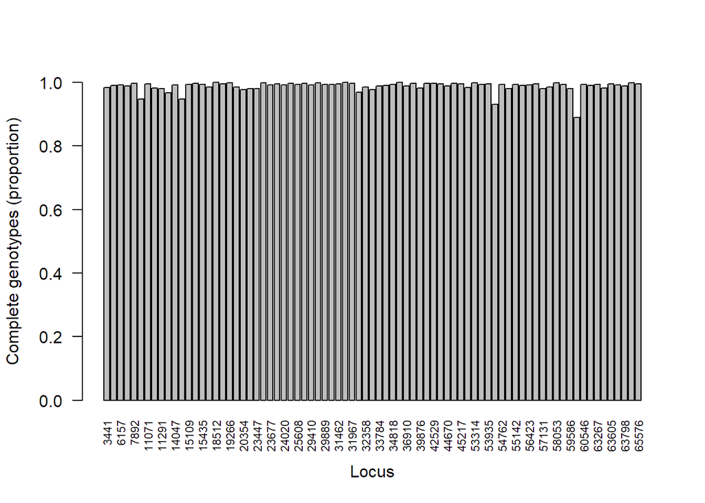

```r
locmiss_lobster = propTyped(lobster_gen, by = "loc")
locmiss_lobster[which(locmiss_lobster < 0.80)] # print loci with < 80% complete genotypes
## named numeric(0)

# Barplot
barplot(locmiss_lobster, ylim = c(0,1), ylab = "Complete genotypes (proportion)", xlab = "Locus", las = 2, cex.names = 0.7)
```

Calculate the percentage of complete genotypes per loci in the pink sea fan microsatellite data set.

```r
locmiss_seafan = propTyped(seafan_gen, by = "loc")
locmiss_seafan[which(locmiss_seafan < 0.80)] # print loci with < 80% complete genotypes
```

```
##   Ever012
## 0.6294185
```

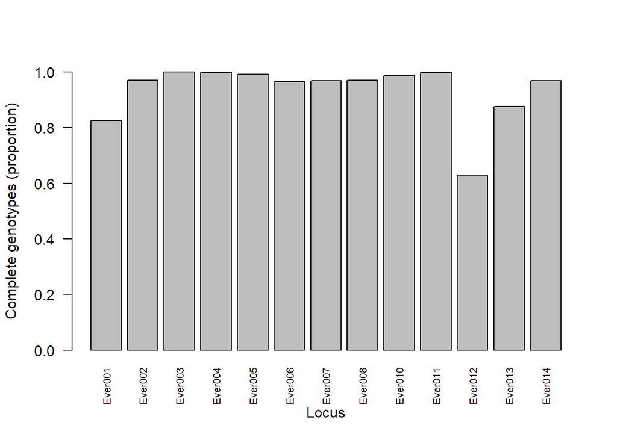

```r
# Barplot
barplot(locmiss_seafan, ylim = c(0,1), ylab = "Complete genotypes (proportion)", xlab = "Locus", las = 2, cex.names = 0.7)
```

Remove microsatellite loci with > 20% missing data.

```r
seafan_gen = missingno(seafan_gen, type = "loci", cutoff = 0.20)
```

```
##
## Found 6873 missing values.
##
## 1 locus contained missing values greater than 20%
##
## Removing 1 locus: , Ever012
```

#### Missing data: individuals

Calculate the percentage of complete genotypes per individual in the lobster SNP data set.

```r
indmiss_lobster = propTyped(lobster_gen, by = "ind")
indmiss_lobster[ which(indmiss_lobster < 0.80) ] # print individuals with < 80% complete genotypes
```

```
##     Ale04     Ale06     Ale08     Ale13     Ale15     Ale16     Ale19     Sin65
## 0.4936709 0.5063291 0.5443038 0.5696203 0.4556962 0.5316456 0.4430380 0.7848101
##     The24
## 0.5696203
```

Remove individuals with > 20% missing genotypes.

```r
lobster_gen = missingno(lobster_gen, type = "geno", cutoff = 0.20)
```

```
##
## Found 2590 missing values.
##
## 9 genotypes contained missing values greater than 20%
##
## Removing 9 genotypes: Ale04, Ale06, Ale08, Ale13, Ale15, Ale16, Ale19,
## Sin65, The24
```

Calculate the percentage of complete genotypes per individual in the pink sea fan microsatellite data set.

```r
indmiss_seafan= propTyped(seafan_gen, by = "ind")
indmiss_seafan[ which(indmiss_seafan < 0.80) ] # print individuals with < 80% complete genotypes
```

```
##  ArmIII_9 ArmIII_31      Bov1     Bov39     Lao11     Lao13     Lao16     Lao34
##      0.75      0.75      0.75      0.75      0.75      0.75      0.75      0.75
##     Lun19      Moh8     Moh29   PorI_25   PorI_33   PorI_40   PorII_7     Rag14
##      0.75      0.75      0.75      0.75      0.75      0.75      0.75      0.75
##   RosI_33  RosII_36     Vol21
##      0.75      0.75      0.75
```

Remove individuals with > 20% missing genotypes.

```r
seafan_gen = missingno(seafan_gen, type = "geno", cutoff = 0.20)
```

```
##
## Found 5248 missing values.
##
## 19 genotypes contained missing values greater than 20%
##
## Removing 19 genotypes: ArmIII_9, ArmIII_31, Bov1, Bov39, Lao11, Lao13,
## Lao16, Lao34, Lun19, Moh8, Moh29, PorI_25, PorI_33, PorI_40, PorII_7,
## Rag14, RosI_33, RosII_36, Vol21
```

#### Check genotypes are unique

Check all individual genotypes are unique. Duplicated genotypes can result from unintentionally sampling the same individual twice or from sampling clones.

```r
# Print the number of multilocus genotypes
mlg(lobster_gen)
## #############################
## # Number of Individuals:  1296
## # Number of MLG:  1271
## #############################
## [1] 1271

mlg(seafan_gen)
## #############################
## # Number of Individuals:  858
## # Number of MLG:  857
## #############################
## [1] 857
```

Identify duplicated genotypes.

```r
dups_lobster = mlg.id(lobster_gen)
for (i in dups_lobster){ # for each element in the list object
  if (length(dups_lobster[i]) > 1){ # if the length is greater than 1
    print(i) # print individuals that are duplicates
  }
}
```

```
## [1] "Laz4" "Tar4"
## [1] "Eye15" "Eye16" "Eye35"
## [1] "Eye01" "Eye17"
## [1] "Laz2" "Tar2"
## [1] "Eye08" "Eye41"
## [1] "Gul101" "Gul86"
## [1] "Eye25" "Eye29"
## [1] "Iom02" "Iom22"
## [1] "Hel07" "Hel09"
## [1] "Eye27" "Eye42"
## [1] "Eye05" "Eye06" "Eye23" "Eye40"
## [1] "Eye22" "Eye38"
## [1] "Eye11" "Eye32"
## [1] "Cro08" "Cro15"
## [1] "Laz1" "Tar1"
## [1] "Eye14" "Eye31"
## [1] "Laz3" "Tar3"
## [1] "Lyn04" "Lyn15" "Lyn34"
## [1] "Eye07" "Eye24"
## [1] "Eye02" "Eye04"
## [1] "Eye20" "Eye36"
```

```r
dups_seafan = mlg.id(seafan_gen)
for (i in dups_seafan){ # for each element in the list object
  if (length(dups_seafan[i]) > 1){ # if the length is greater than 1
    print(i) # print individuals that are duplicates
  }
}
```

```
## [1] "ArmI_15" "ArmII_2"
```

Remove duplicated genotypes.

```r
# Create a vector of individuals to remove
lob_dups = c("Laz4","Eye15","Eye16","Eye01","Laz2","Eye08","Gul101","Eye25","Iom02","Hel07","Eye27","Eye05","Eye06","Eye23","Eye22","Eye11","Cro08","Tar1","Eye14","Tar3","Lyn04","Lyn15","Eye07","Eye02","Eye20")
psf_dups = c("ArmI_15")
```

```r
# Create a vector of individual names without the duplicates
lob_Nodups = indNames(lobster_gen)[! indNames(lobster_gen) %in% lob_dups]
psf_Nodups = indNames(seafan_gen)[! indNames(seafan_gen) %in% psf_dups]
```

```r
# Create a new genind object without the duplicates
lobster_gen = lobster_gen[lob_Nodups, ]
seafan_gen = seafan_gen[psf_Nodups, ]
```

```r
# Re-print the number of multilocus genotypes
mlg(lobster_gen)
## #############################
## # Number of Individuals:  1271
## # Number of MLG:  1271
## #############################
## [1] 1271

mlg(seafan_gen)
## #############################
## # Number of Individuals:  857
## # Number of MLG:  857
## #############################
## [1] 857
```

#### Check loci are still polymorphic after filtering

```r
isPoly(lobster_gen) %>% summary
```

```
##    Mode    TRUE
## logical      79
```

```r
isPoly(seafan_gen) %>% summary
```

```
##    Mode   FALSE    TRUE
## logical       1      11
```

Remove loci that are not polymorphic.

```r
poly_loci = names(which(isPoly(seafan_gen) == TRUE))
seafan_gen = seafan_gen[loc = poly_loci]
isPoly(seafan_gen) %>% summary
```

```
##    Mode    TRUE
## logical      11
```

Back to Contents

### 4. Summary statistics

#### Print basic info

```r
lobster_gen
## /// GENIND OBJECT /////////
##
##  // 1,271 individuals; 79 loci; 158 alleles; size: 921.5 Kb
##
##  // Basic content
##    @tab:  1271 x 158 matrix of allele counts
##    @loc.n.all: number of alleles per locus (range: 2-2)
##    @loc.fac: locus factor for the 158 columns of @tab
##    @all.names: list of allele names for each locus
##    @ploidy: ploidy of each individual  (range: 2-2)
##    @type:  codom
##    @call: .local(x = x, i = i, j = j, drop = drop)
##
##  // Optional content
##    @pop: population of each individual (group size range: 5-40)

seafan_gen
## /// GENIND OBJECT /////////
##
##  // 857 individuals; 11 loci; 106 alleles; size: 439.8 Kb
##
##  // Basic content
##    @tab:  857 x 106 matrix of allele counts
##    @loc.n.all: number of alleles per locus (range: 2-18)
##    @loc.fac: locus factor for the 106 columns of @tab
##    @all.names: list of allele names for each locus
##    @ploidy: ploidy of each individual  (range: 2-2)
##    @type:  codom
##    @call: .local(x = x, i = i, j = j, loc = ..1, drop = drop)
##
##  // Optional content
##    @pop: population of each individual (group size range: 21-48)
```

#### Print the number of alleles per locus

```r
table(lobster_gen$loc.fac)
```

```
##
##  3441  4173  6157  7502  7892  9441 11071 11183 11291 12971 14047 14742 15109
##     2     2     2     2     2     2     2     2     2     2     2     2     2
## 15128 15435 15581 18512 18652 19266 19460 20354 23146 23447 23481 23677 23787
##     2     2     2     2     2     2     2     2     2     2     2     2     2
## 24020 25229 25608 27329 29410 29801 29889 30339 31462 31618 31967 31979 32358
##     2     2     2     2     2     2     2     2     2     2     2     2     2
## 32435 33784 34443 34818 35584 36910 39107 39876 42395 42529 42821 44670 45154
##     2     2     2     2     2     2     2     2     2     2     2     2     2
## 45217 51159 53314 53720 53935 54240 54762 55111 55142 55564 56423 56785 57131
##     2     2     2     2     2     2     2     2     2     2     2     2     2
## 57989 58053 59503 59586 59967 60546 63140 63267 63581 63605 63771 63798 65064
##     2     2     2     2     2     2     2     2     2     2     2     2     2
## 65576
##     2
```

```r
table(seafan_gen$loc.fac)
```

```
##
## Ever001 Ever002 Ever003 Ever004 Ever006 Ever007 Ever008 Ever010 Ever011 Ever013
##      15       5       5      13      18      11       2       9       5      14
## Ever014
##       9
```

#### Print the sample size for each site

```r
summary(lobster_gen$pop)
```

```
##   Ale   Ber   Brd   Cor   Cro   Eye   Flo   Gul   Heb   Hel   Hoo Idr16 Idr17
##    28    33    36    32    35    26    36    35    36    35    36    32    29
##   Iom   Ios   Jer   Kav   Kil   Laz   Loo   Lyn   Lys   Mul   Oos   Ork   Pad
##    35    36    36    36    35     5    36    34    36    36    40    36    36
##   Pem Sar13 Sar17   Sbs   She   Sin   Sky   Sul   Tar   The   Tor   Tro   Ven
##    36     7    15    36    36    35    37    36     5    36    37    17    36
##   Vig
##    36
```

```r
summary(seafan_gen$pop)
```

```
##   ArmI  ArmII ArmIII    Bla    Bov    Bre    Far    Fla    Han    Lao    Lio
##     26     43     39     29     38     43     44     23     36     36     22
##    Lun    Men    Mew    Moh   PorI  PorII    Rag   RosI  RosII    Sko    Thu
##     21     43     44     28     39     34     42     39     35     39     48
##    Vol    Wtn
##     23     43
```

#### Print the number of private alleles per site across all loci

```r
private_alleles(seafan_gen) %>% apply(MARGIN = 1, FUN = sum)
```

```
##   ArmI  ArmII ArmIII    Bla    Bov    Bre    Far    Fla    Han    Lao    Lio
##      1      1      0      0      0      0      1      0      0      1      0
##    Lun    Men    Mew    Moh   PorI  PorII    Rag   RosI  RosII    Sko    Thu
##      1      1      1      0      1      4      0      2      1      0      2
##    Vol    Wtn
##      0      0
```

#### Print mean allelic richness per site across all loci

```r
allelic.richness(genind2hierfstat(seafan_gen))$Ar %>%
  apply(MARGIN = 2, FUN = mean) %>%
  round(digits = 3)
```

```
##   ArmI  ArmII ArmIII    Bla    Bov    Bre    Far    Fla    Han    Lao    Lio
##  2.771  2.720  2.748  2.635  2.784  2.837  2.807  2.698  3.030  2.809  2.957
##    Lun    Men    Mew    Moh   PorI  PorII    Rag   RosI  RosII    Sko    Thu
##  2.915  2.824  2.895  2.791  2.900  2.833  2.895  2.831  2.966  2.905  2.650
##    Vol    Wtn
##  2.767  3.032
```

#### Calculate heterozygosity per site

```r
# Calculate basic stats using hierfstat
basic_lobster = basic.stats(lobster_gen, diploid = TRUE)
basic_seafan = basic.stats(seafan_gen, diploid = TRUE)
```

```r
# Mean observed heterozygosity per site
Ho_lobster = apply(basic_lobster$Ho, MARGIN = 2, FUN = mean, na.rm = TRUE) %>%
  round(digits = 2)
Ho_lobster
```

```
##   Ale   Ber   Brd   Cor   Cro   Eye   Flo   Gul   Heb   Hel   Hoo Idr16 Idr17
##  0.32  0.36  0.37  0.38  0.37  0.37  0.35  0.38  0.39  0.35  0.39  0.39  0.39
##   Iom   Ios   Jer   Kav   Kil   Laz   Loo   Lyn   Lys   Mul   Oos   Ork   Pad
##  0.39  0.39  0.38  0.37  0.38  0.38  0.39  0.40  0.34  0.37  0.32  0.36  0.37
##   Pem Sar13 Sar17   Sbs   She   Sin   Sky   Sul   Tar   The   Tor   Tro   Ven
##  0.38  0.32  0.34  0.38  0.37  0.35  0.33  0.36  0.42  0.33  0.33  0.33  0.39
##   Vig
##  0.39
```

```r
Ho_seafan = apply(basic_seafan$Ho, MARGIN = 2, FUN = mean, na.rm = TRUE) %>%
  round(digits = 2)
Ho_seafan
```

```
##   ArmI  ArmII ArmIII    Bla    Bov    Bre    Far    Fla    Han    Lao    Lio
##   0.41   0.45   0.44   0.44   0.45   0.46   0.43   0.47   0.50   0.45   0.50
##    Lun    Men    Mew    Moh   PorI  PorII    Rag   RosI  RosII    Sko    Thu
##   0.49   0.47   0.51   0.41   0.44   0.45   0.51   0.49   0.49   0.53   0.40
##    Vol    Wtn
##   0.47   0.50
```

```r
# Mean expected heterozygosity per site
He_lobster = apply(basic_lobster$Hs, MARGIN = 2, FUN = mean, na.rm = TRUE) %>%
  round(digits = 2)
He_lobster
```

```
##   Ale   Ber   Brd   Cor   Cro   Eye   Flo   Gul   Heb   Hel   Hoo Idr16 Idr17
##  0.34  0.36  0.37  0.39  0.37  0.37  0.35  0.36  0.38  0.35  0.39  0.39  0.39
##   Iom   Ios   Jer   Kav   Kil   Laz   Loo   Lyn   Lys   Mul   Oos   Ork   Pad
##  0.39  0.39  0.38  0.36  0.38  0.34  0.37  0.39  0.35  0.38  0.33  0.37  0.37
##   Pem Sar13 Sar17   Sbs   She   Sin   Sky   Sul   Tar   The   Tor   Tro   Ven
##  0.38  0.32  0.35  0.37  0.37  0.35  0.33  0.37  0.36  0.34  0.33  0.36  0.38
##   Vig
##  0.39
```

```r
He_seafan = apply(basic_seafan$Hs, MARGIN = 2, FUN = mean, na.rm = TRUE) %>%
  round(digits = 2)
He_seafan
```

```
##   ArmI  ArmII ArmIII    Bla    Bov    Bre    Far    Fla    Han    Lao    Lio
##   0.48   0.47   0.48   0.44   0.50   0.49   0.48   0.47   0.54   0.50   0.52
##    Lun    Men    Mew    Moh   PorI  PorII    Rag   RosI  RosII    Sko    Thu
##   0.52   0.50   0.53   0.49   0.51   0.50   0.51   0.50   0.53   0.53   0.43
##    Vol    Wtn
##   0.49   0.54
```

#### Visualise heterozygosity per site

```r
# Create a data.frame of site names, Ho and He and then convert to long format
Het_lobster_df = data.frame(Site = names(Ho_lobster), Ho = Ho_lobster, He = He_lobster) %>%
  melt(id.vars = "Site")
Het_seafan_df = data.frame(Site = names(Ho_seafan), Ho = Ho_seafan, He = He_seafan) %>%
  melt(id.vars = "Site")
```

```r
# Custom theme for ggplot2
custom_theme = theme(
  axis.text.x = element_text(size = 10, angle = 90, vjust = 0.5, face = "bold"),
  axis.text.y = element_text(size = 10),
  axis.title.y = element_text(size = 12),
  axis.title.x = element_blank(),
  axis.line.y = element_line(size = 0.5),
  legend.title = element_blank(),
  legend.text = element_text(size = 12),
  panel.grid = element_blank(),
  panel.background = element_blank(),
  plot.title = element_text(hjust = 0.5, size = 15, face="bold")
  )

# Italic label
hetlab.o = expression(italic("H")[o])
hetlab.e = expression(italic("H")[e])
```

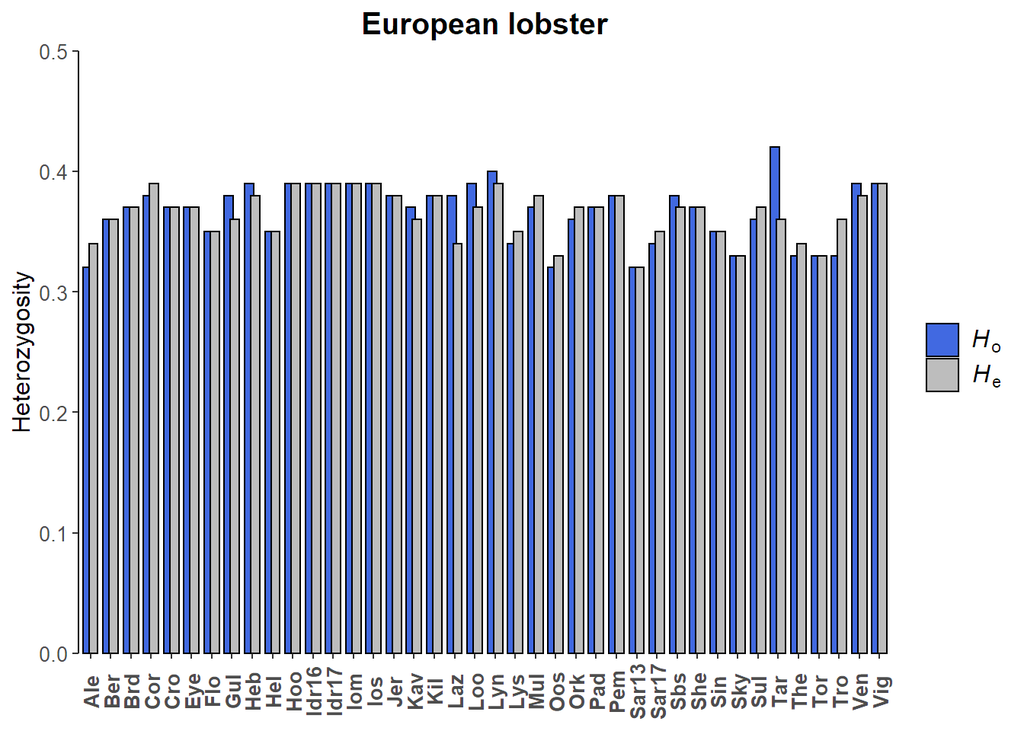

```r
# Lobster heterozygosity barplot
ggplot(data = Het_lobster_df, aes(x = Site, y = value, fill = variable))+
  geom_bar(stat = "identity", position = position_dodge(width = 0.6), colour = "black")+
  scale_y_continuous(expand = c(0,0), limits = c(0,0.50))+
  scale_fill_manual(values = c("royalblue", "#bdbdbd"), labels = c(hetlab.o, hetlab.e))+
  ylab("Heterozygosity")+
  ggtitle("European lobster")+
  custom_theme
```

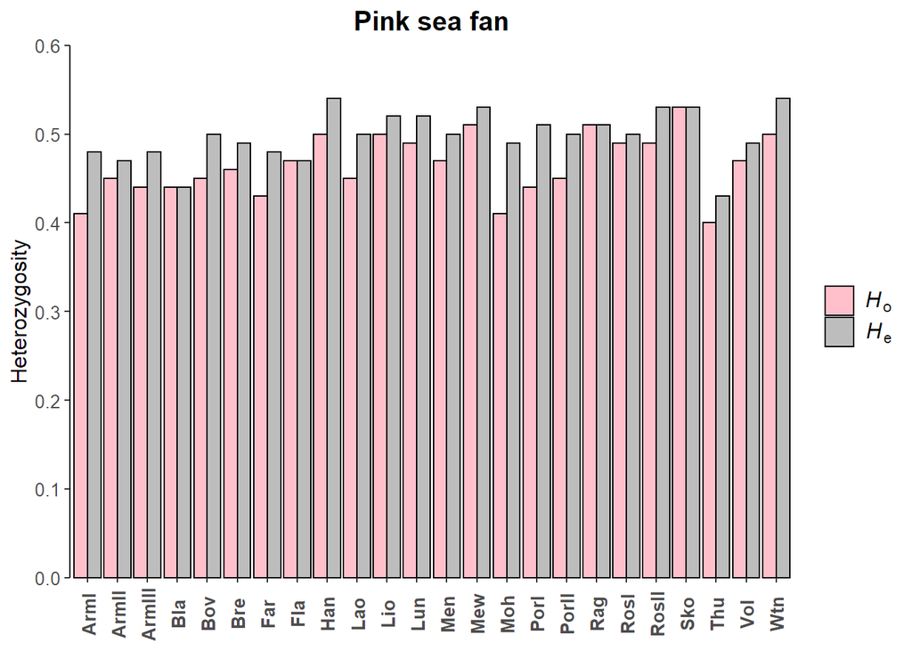

```r
# Pink sea fan heterozygosity barplot
ggplot(data = Het_seafan_df, aes(x = Site, y = value, fill = variable))+
  geom_bar(stat = "identity", position = "dodge", colour = "black")+
  scale_y_continuous(expand = c(0,0), limits = c(0,0.60), breaks = c(0, 0.10, 0.20, 0.30, 0.40, 0.50, 0.60))+
  scale_fill_manual(values = c("pink", "#bdbdbd"), labels = c(hetlab.o, hetlab.e))+
  ylab("Heterozygosity")+
  ggtitle("Pink sea fan")+
  custom_theme
```

#### Inbreeding coefficient (*F*<sub>IS</sub>)

Calculate mean *F*<sub>IS</sub> per site.

```r
# European lobster
apply(basic_lobster$Fis, MARGIN = 2, FUN = mean, na.rm = TRUE) %>%
  round(digits = 3)
```

```
##    Ale    Ber    Brd    Cor    Cro    Eye    Flo    Gul    Heb    Hel    Hoo
##  0.057  0.003  0.003  0.021 -0.006 -0.004  0.005 -0.044 -0.034  0.013 -0.016
##  Idr16  Idr17    Iom    Ios    Jer    Kav    Kil    Laz    Loo    Lyn    Lys
## -0.007 -0.001 -0.024 -0.007  0.004 -0.024 -0.016 -0.115 -0.043 -0.032  0.018
##    Mul    Oos    Ork    Pad    Pem  Sar13  Sar17    Sbs    She    Sin    Sky
##  0.040  0.023  0.017 -0.010 -0.004 -0.009  0.018 -0.017 -0.006 -0.013  0.006
##    Sul    Tar    The    Tor    Tro    Ven    Vig
##  0.033 -0.153  0.029  0.010  0.066 -0.024  0.013
```

```r
# Pink sea fan
apply(basic_seafan$Fis, MARGIN = 2, FUN = mean, na.rm = TRUE) %>%
  round(digits = 3)
```

```
##   ArmI  ArmII ArmIII    Bla    Bov    Bre    Far    Fla    Han    Lao    Lio
##  0.166  0.085  0.076 -0.006  0.075  0.039  0.116  0.014  0.042  0.064  0.029
##    Lun    Men    Mew    Moh   PorI  PorII    Rag   RosI  RosII    Sko    Thu
##  0.057  0.067  0.030  0.153  0.137  0.089  0.010  0.048  0.077  0.013  0.056
##    Vol    Wtn
##  0.057  0.058
```

Back to Contents

### 5. *F*<sub>ST</sub>, PCA & DAPC

#### *F*<sub>ST</sub>

Compute pairwise *F*<sub>ST</sub> (Weir & Cockerham 1984).

```r
# Subset data sets to reduce computation time
lobster_gen_sub = popsub(lobster_gen, sublist = c("Ale","Ber","Brd","Pad","Sar17","Vig"))
seafan_gen_sub = popsub(seafan_gen, sublist = c("Bla","Bov","Bre","Lun","PorI","Sko"))

# Compute pairwise Fsts
lobster_fst = genet.dist(lobster_gen_sub, method = "WC84")
lobster_fst %>% round(digits = 3)
```

```
##         Ale   Ber   Brd   Pad Sar17
## Ber   0.120
## Brd   0.131 0.007
## Pad   0.140 0.025 0.008
## Sar17 0.066 0.174 0.171 0.161
## Vig   0.117 0.064 0.038 0.018 0.112
```

```r
seafan_fst = genet.dist(seafan_gen_sub, method = "WC84")
seafan_fst %>% round(digits = 3)
```

```
##         Bla    Bov    Bre    Lun   PorI
## Bov   0.099
## Bre   0.105  0.005
## Lun   0.095 -0.002  0.012
## PorI  0.114  0.052  0.045  0.045
## Sko   0.094 -0.002  0.006 -0.001  0.041
```

Visualise pairwise *F*<sub>ST</sub> for lobster.

```r
# Convert dist object to data.frame
fst.matrix = as.matrix(lobster_fst)
ind = which( upper.tri(fst.matrix), arr.ind = TRUE)
fst.df = data.frame(Site1 = dimnames(fst.matrix)[[2]][ind[,2]],
                    Site2 = dimnames(fst.matrix)[[1]][ind[,1]],
                    Fst = fst.matrix[ ind ] %>% round(digits = 3))

# Convert minus values to zero
fst.df$Fst[fst.df$Fst < 0] = 0

# Print data.frame summary
fst.df %>% str
```

```
## 'data.frame':    15 obs. of  3 variables:
##  $ Site1: chr  "Ber" "Brd" "Brd" "Pad" ...
##  $ Site2: chr  "Ale" "Ale" "Ber" "Ale" ...
##  $ Fst  : num  0.12 0.131 0.007 0.14 0.025 0.008 0.066 0.174 0.171 0.161 ...
```

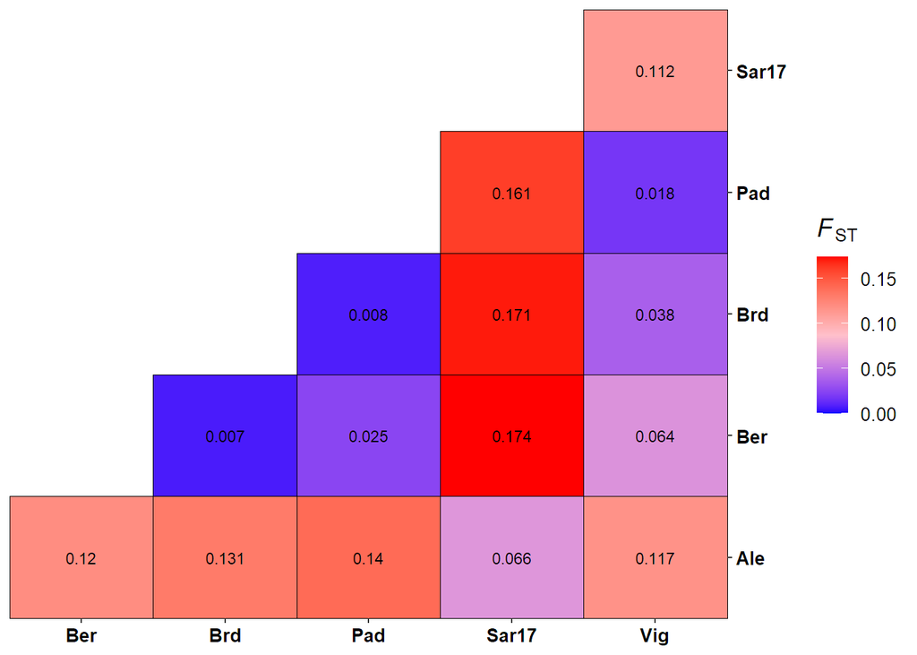

```r
# Fst italic label
fst.label = expression(italic("F")[ST])

# Extract middle Fst value for gradient argument
mid = max(fst.df$Fst) / 2

# Plot heatmap
ggplot(data = fst.df, aes(x = Site1, y = Site2, fill = Fst))+
  geom_tile(colour = "black")+
  geom_text(aes(label = Fst), color="black", size = 3)+
  scale_fill_gradient2(low = "blue", mid = "pink", high = "red", midpoint = mid, name = fst.label, limits = c(0, max(fst.df$Fst)), breaks = c(0, 0.05, 0.10, 0.15))+
  scale_x_discrete(expand = c(0,0))+
  scale_y_discrete(expand = c(0,0), position = "right")+
  theme(axis.text = element_text(colour = "black", size = 10, face = "bold"),
        axis.title = element_blank(),
        panel.grid = element_blank(),
        panel.background = element_blank(),
        legend.position = "right",
        legend.title = element_text(size = 14, face = "bold"),
        legend.text = element_text(size = 10)
        )
```

Visualise pairwise *F*<sub>ST</sub> for pink sea fan.

```r
# Convert dist object to data.frame
fst.matrix = as.matrix(seafan_fst)
ind = which( upper.tri(fst.matrix), arr.ind = TRUE)
fst.df = data.frame(Site1 = dimnames(fst.matrix)[[2]][ind[,2]],
                    Site2 = dimnames(fst.matrix)[[1]][ind[,1]],
                    Fst = fst.matrix[ ind ] %>% round(digits = 3))

# Convert minus values to zero
fst.df$Fst[fst.df$Fst < 0] = 0

# Print data.frame summary
fst.df %>% str
```

```
## 'data.frame':    15 obs. of  3 variables:
##  $ Site1: chr  "Bov" "Bre" "Bre" "Lun" ...
##  $ Site2: chr  "Bla" "Bla" "Bov" "Bla" ...
##  $ Fst  : num  0.099 0.105 0.005 0.095 0 0.012 0.114 0.052 0.045 0.045 ...
```

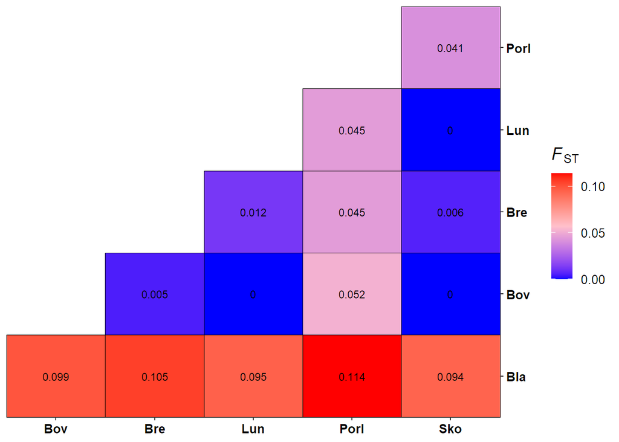

```r
# Fst italic label
fst.label = expression(italic("F")[ST])

# Extract middle Fst value for gradient argument
mid = max(fst.df$Fst) / 2

# Plot heatmap
ggplot(data = fst.df, aes(x = Site1, y = Site2, fill = Fst))+
  geom_tile(colour = "black")+
  geom_text(aes(label = Fst), color="black", size = 3)+
  scale_fill_gradient2(low = "blue", mid = "pink", high = "red", midpoint = mid, name = fst.label, limits = c(0, max(fst.df$Fst)), breaks = c(0, 0.05, 0.10))+
  scale_x_discrete(expand = c(0,0))+
  scale_y_discrete(expand = c(0,0), position = "right")+
  theme(axis.text = element_text(colour = "black", size = 10, face = "bold"),
        axis.title = element_blank(),
        panel.grid = element_blank(),
        panel.background = element_blank(),
        legend.position = "right",
        legend.title = element_text(size = 14, face = "bold"),
        legend.text = element_text(size = 10)
        )
```

#### PCA

Perform a PCA (principle components analysis) on the lobster data set.

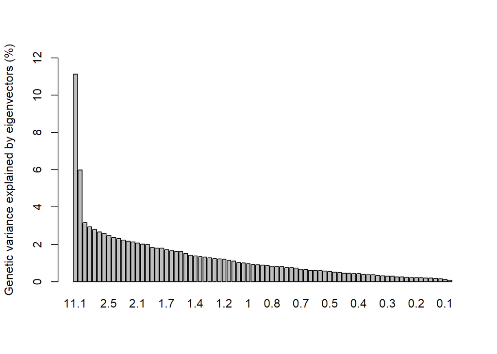

```r
# Replace missing data with the mean allele frequencies
x = tab(lobster_gen_sub, NA.method = "mean")

# Perform PCA
pca1 = dudi.pca(x, scannf = FALSE, scale = FALSE, nf = 3)

# Analyse how much percent of genetic variance is explained by each axis
percent = pca1$eig/sum(pca1$eig)*100
barplot(percent, ylab = "Genetic variance explained by eigenvectors (%)",
        names.arg = round(percent, 1), ylim = c(0, 12))
```

Visualise PCA results.

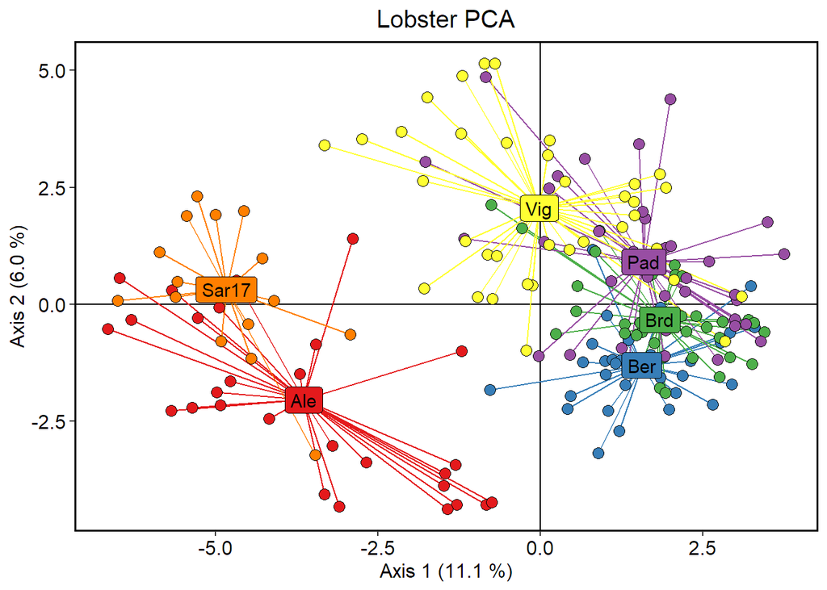

```r
# Create a data.frame containing individual coordinates
ind_coords = as.data.frame(pca1$li)

# Rename columns of dataframe
colnames(ind_coords) = c("Axis1","Axis2","Axis3")

# Add a column containing individuals
ind_coords$Ind = indNames(lobster_gen_sub)

# Add a column with the site IDs
ind_coords$Site = lobster_gen_sub$pop

# Calculate centroid (average) position for each population
centroid = aggregate(cbind(Axis1, Axis2, Axis3) ~ Site, data = ind_coords, FUN = mean)

# Add centroid coordinates to ind_coords dataframe
ind_coords = left_join(ind_coords, centroid, by = "Site", suffix = c("",".cen"))

# Define colour palette
cols = brewer.pal(nPop(lobster_gen_sub), "Set1")

# Custom x and y labels
xlab = paste("Axis 1 (", format(round(percent[1], 1), nsmall=1)," %)", sep="")
ylab = paste("Axis 2 (", format(round(percent[2], 1), nsmall=1)," %)", sep="")

# Custom theme for ggplot2
ggtheme = theme(axis.text.y = element_text(colour="black", size=12),
                axis.text.x = element_text(colour="black", size=12),
                axis.title = element_text(colour="black", size=12),
                panel.border = element_rect(colour="black", fill=NA, size=1),
                panel.background = element_blank(),
                plot.title = element_text(hjust=0.5, size=15)
)

# Scatter plot axis 1 vs. 2
ggplot(data = ind_coords, aes(x = Axis1, y = Axis2))+
  geom_hline(yintercept = 0)+
  geom_vline(xintercept = 0)+
  # spider segments
  geom_segment(aes(xend = Axis1.cen, yend = Axis2.cen, colour = Site), show.legend = FALSE)+
  # points
  geom_point(aes(fill = Site), shape = 21, size = 3, show.legend = FALSE)+
  # centroids
  geom_label(data = centroid, aes(label = Site, fill = Site), size = 4, show.legend = FALSE)+
  # colouring
  scale_fill_manual(values = cols)+
  scale_colour_manual(values = cols)+
  # custom labels
  labs(x = xlab, y = ylab)+
  ggtitle("Lobster PCA")+
  # custom theme
  ggtheme
```

#### DAPC

Perform a DAPC (discriminant analysis of principal components) on the seafan data set.

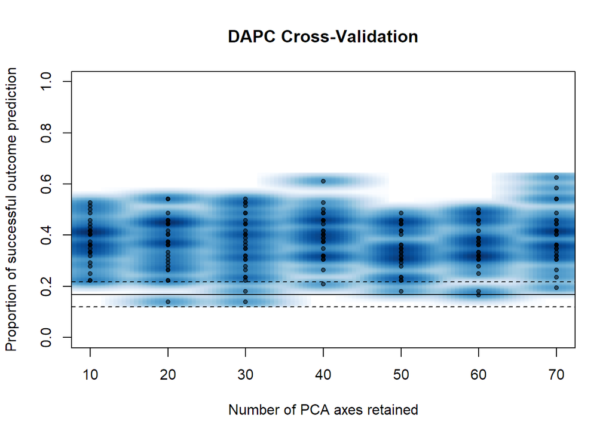

```r
# Perform cross validation to find the optimal number of PCs to retain in DAPC
set.seed(123)
x = tab(seafan_gen_sub, NA.method = "mean")
crossval = xvalDapc(x, seafan_gen_sub$pop, result = "groupMean", xval.plot = TRUE)
```

```r
# Number of PCs with best stats (lower score = better)
crossval$`Root Mean Squared Error by Number of PCs of PCA`
```

```
##        10        20        30        40        50        60        70
## 0.6252777 0.6326131 0.6380681 0.6057849 0.6587395 0.6412447 0.6113320
```

```r
crossval$`Number of PCs Achieving Highest Mean Success`
```

```
## [1] "40"
```

```r
crossval$`Number of PCs Achieving Lowest MSE`
```

```
## [1] "40"
```

```r
numPCs = as.numeric(crossval$`Number of PCs Achieving Lowest MSE`)
```

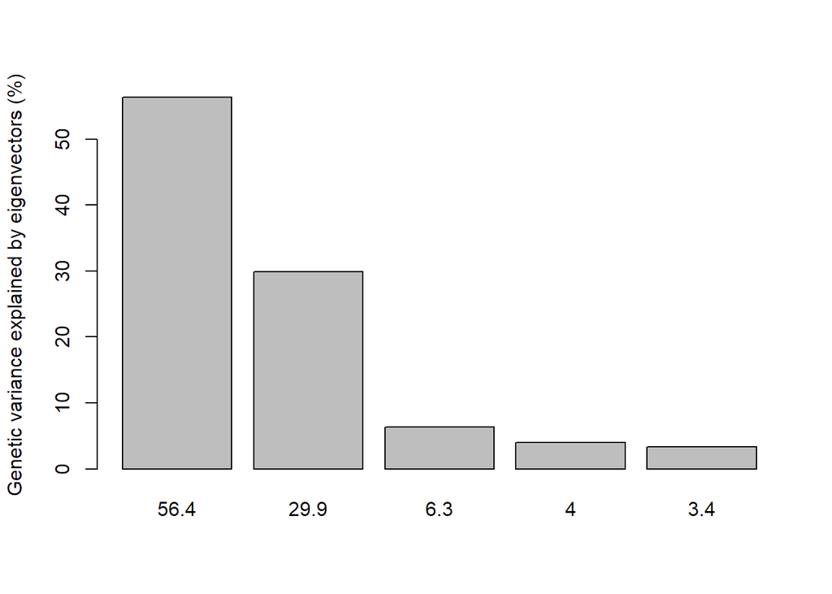

```r
# Run a DAPC using site IDs as priors
dapc1 = dapc(seafan_gen_sub, seafan_gen_sub$pop, n.pca = numPCs, n.da = 3)

# Analyse how much percent of genetic variance is explained by each axis
percent = dapc1$eig/sum(dapc1$eig)*100
barplot(percent, ylab = "Genetic variance explained by eigenvectors (%)",
        names.arg = round(percent, 1))
```

Visualise DAPC results.

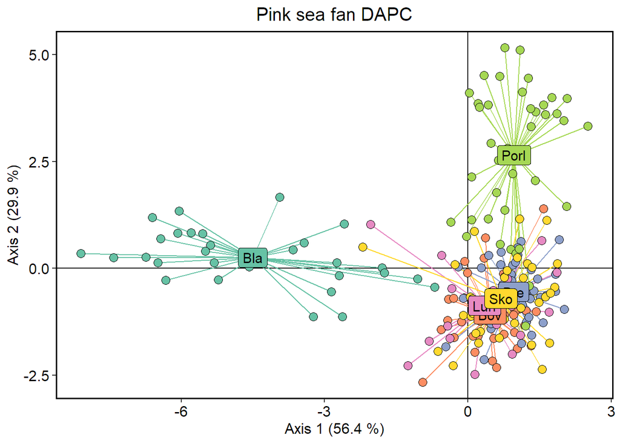

```r
# Create a data.frame containing individual coordinates
ind_coords = as.data.frame(dapc1$ind.coord)

# Rename columns of dataframe
colnames(ind_coords) = c("Axis1","Axis2","Axis3")

# Add a column containing individuals
ind_coords$Ind = indNames(seafan_gen_sub)

# Add a column with the site IDs
ind_coords$Site = seafan_gen_sub$pop

# Calculate centroid (average) position for each population
centroid = aggregate(cbind(Axis1, Axis2, Axis3) ~ Site, data = ind_coords, FUN = mean)

# Add centroid coordinates to ind_coords dataframe
ind_coords = left_join(ind_coords, centroid, by = "Site", suffix = c("",".cen"))

# Define colour palette
cols = brewer.pal(nPop(seafan_gen_sub), "Set2")

# Custom x and y labels
xlab = paste("Axis 1 (", format(round(percent[1], 1), nsmall=1)," %)", sep="")
ylab = paste("Axis 2 (", format(round(percent[2], 1), nsmall=1)," %)", sep="")

# Scatter plot axis 1 vs. 2
ggplot(data = ind_coords, aes(x = Axis1, y = Axis2))+
  geom_hline(yintercept = 0)+
  geom_vline(xintercept = 0)+
  # spider segments
  geom_segment(aes(xend = Axis1.cen, yend = Axis2.cen, colour = Site), show.legend = FALSE)+
  # points
  geom_point(aes(fill = Site), shape = 21, size = 3, show.legend = FALSE)+
  # centroids
  geom_label(data = centroid, aes(label = Site, fill = Site), size = 4, show.legend = FALSE)+
  # colouring
  scale_fill_manual(values = cols)+
  scale_colour_manual(values = cols)+
  # custom labels
  labs(x = xlab, y = ylab)+
  ggtitle("Pink sea fan DAPC")+
  # custom theme
  ggtheme
```

Back to Contents

### 6. Extras

#### Import VCF file

To illustrate importing VCF files and conducting OutFLANK outlier selection tests in R, we will use an [American lobster SNP data set](https://doi.org/10.5061/dryad.q771r) available from the Dryad Digital Repository.

```r
# Load vcfR package
library(vcfR)

# Import only 3,000 variants to reduce computation time
american = read.vcfR("10156-586.recode.vcf", nrows = 3000, verbose = FALSE)
american
## ***** Object of Class vcfR *****
## 586 samples
## 1 CHROMs
## 3,000 variants
## Object size: 16.6 Mb
## 0 percent missing data
## *****        *****         *****

# Convert to genind object
american = vcfR2genind(american)

# Add site IDs to genind object
american$pop = as.factor(substr(indNames(american), 1, 3))
```

Back to Contents

#### Conduct outlier tests using OutFLANK

Conduct *F*<sub>ST</sub> differentiation-based outlier tests on `genind` object using OutFLANK using a wrapper script from the [dartR](https://cran.r-project.org/web/packages/dartR/vignettes/IntroTutorial_dartR.pdf) package.

```r
# Load packages
library(OutFLANK)
library(qvalue)
library(dartR)
```

```r
# Run OutFLANK using dartR wrapper script
outflnk = gl.outflank(american, qthreshold = 0.05, plot = FALSE)
## Calculating FSTs, may take a few minutes...

# Extract OutFLANK results
outflnk.df = outflnk$outflank$results

# Remove duplicated rows for each SNP locus
rowsToRemove = seq(1, nrow(outflnk.df), by = 2)
outflnk.df = outflnk.df[-rowsToRemove, ]

# Print number of outliers (TRUE)
outflnk.df$OutlierFlag %>% summary
```

```
##    Mode   FALSE    TRUE
## logical    2968      32
```

```r
# Extract outlier IDs
outlier_indexes = which(outflnk.df$OutlierFlag == TRUE)
outlierID = locNames(american)[outlier_indexes]
outlierID
```

```
##  [1] "un-11566"  "un-69080"  "un-111790" "un-111865" "un-125908" "un-172034"
##  [7] "un-186923" "un-201848" "un-205435" "un-243757" "un-253632" "un-257077"
## [13] "un-288280" "un-288327" "un-342055" "un-395275" "un-395276" "un-424882"
## [19] "un-433799" "un-493905" "un-525474" "un-531991" "un-541424" "un-561940"
## [25] "un-581802" "un-631261" "un-631875" "un-649002" "un-676856" "un-679035"
## [31] "un-691876" "un-734068"
```

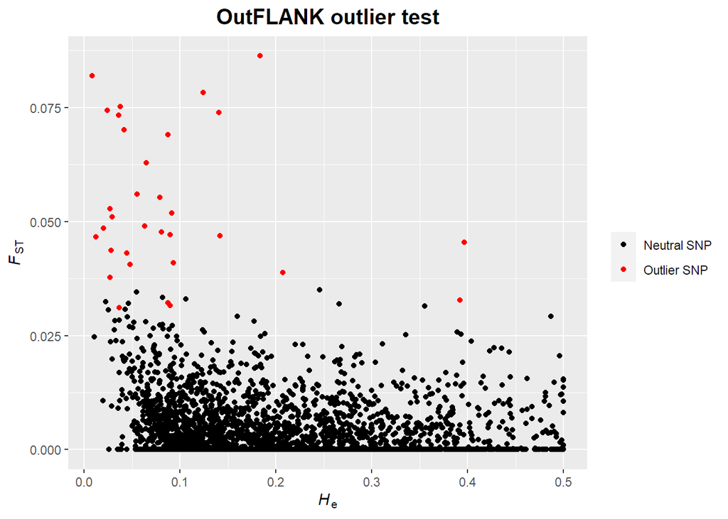

```r
# Convert Fsts <0 to zero
outflnk.df$FST[outflnk.df$FST < 0] = 0

# Italic labels
fstlab = expression(italic("F")[ST])
hetlab = expression(italic("H")[e])

# Plot He versus Fst
ggplot(data = outflnk.df)+
  geom_point(aes(x = He, y = FST, colour = OutlierFlag))+
  scale_colour_manual(values = c("black","red"), labels = c("Neutral SNP","Outlier SNP"))+
  ggtitle("OutFLANK outlier test")+
  xlab(hetlab)+
  ylab(fstlab)+
  theme(legend.title = element_blank(),
        plot.title = element_text(hjust = 0.5, size = 15, face = "bold")
        )
```

Back to Contents

#### Export biallelic SNP genind object

Load required packages.

```r
library(devtools)
library(miscTools)
library(stringr)
```

Export genind object in genepop format.

```r
source_url("https://raw.githubusercontent.com/Tom-Jenkins/utility_scripts/master/TJ_genind2genepop_function.R")
genind2genepop(lobster_gen_sub, file = "lobster_genotypes.gen")
```

Export genind object in STRUCTURE format. If you want to run STRUCTURE in Linux then use `unix = TRUE` which exports a Unix text file (Windows text file default).

```r
source_url("https://raw.githubusercontent.com/Tom-Jenkins/utility_scripts/master/TJ_genind2structure_function.R")
genind2structure(lobster_gen_sub, file = "lobster_genotypes.str", pops = TRUE, markers = TRUE, unix = FALSE)
```

Back to Contents

#### Further resources

[Conduct and visualise admixture analyses in R](https://github.com/Tom-Jenkins/admixture_pie_chart_map_tutorial)  
[Population genetics and genomics in R](https://grunwaldlab.github.io/Population_Genetics_in_R/TOC.html)  
[Detecting multilocus adaptation using redundancy analysis](https://popgen.nescent.org/2018-03-27_RDA_GEA.html)  
[Using pcadapt to detect local adaptation](https://bcm-uga.github.io/pcadapt/articles/pcadapt.html)  
[Analysis of multilocus genotypes and lineages in poppr](https://grunwaldlab.github.io/poppr/articles/mlg.html)  
[Spatial analysis of principal components analysis using adegenet](http://adegenet.r-forge.r-project.org/files/tutorial-spca.pdf)  
[Calculate geographic distances (km) across seas using marmap](https://github.com/Tom-Jenkins/utility_scripts/blob/master/calculate_marine_lc_distances.R)

Back to Contents